# R Notebook: Cardiac feedback analysis

# Introduction

# Load data

Load already pre-processed data (see `pre-processing-AIT.R` for details).

```r
# Load dataset
data <- read_csv('AIT_longformat.csv', col_names=TRUE)

# Select some columns and change their names
df <- data %>%
  transmute(
    id = participant,
    trialN = trials.thisN,
    emo5 = Emotion,
    emo3 = Emotion3,
    fb = feedback,
    bpm_pre = BPM_Pre,
    bpm_post = BPM_Post,
    psc = (BPM_Post-BPM_Pre)/BPM_Pre * 100,
    arousal = arousal.response,
    valence = valenc.response,
    iacc = IAcc,
    iacc_bin = IAccBin
    )
```

Exclusions

- Participants with no Interoceptive Accuracy data (missed recording values)
- 1 participant missing value
- Participants with extreme PSC values

```r
# NA in IACC column
excluded_iacc <- c(8,17,29,40,42,45,50,52,53)
# mysterious NA in id
# 23 bad, 15 good, 11 NA
excluded_psc <- c(5,23,35,36,37,38,39,40,51)
#excluded_psc <- c(3,9,23,30,35,36,37,38,49,51,54,57)
#excluded_psc <- c(3,9,23,35,36,37,51,57)

df <- df %>%
  na.omit() %>%
  filter(!(id %in% excluded_iacc)) %>%
  filter(!(id %in% excluded_psc)) %>%
  filter(psc > -15 & psc < 15) # filter unwanted values (PSC)
```

# Hypotheses and analysis plan

### Hypotheses

1. Manipulation check of arousal induction
1. Image category (pos, neg, neutral) will influence arousal ratings : Within-subject ANOVA (arousal ~ category)
2. Image category (pos, neg, neutral) will influence valence ratings : Within-subject ANOVA (valence ~ category)
3. Image category (pos, neg, neutral) will influence HR deceleration : Within-subject ANOVA (hr ~ category)
1. HR is correlated with arousal ratings : Pearson’s correlation (hr x arousal)
2. HR is not correlated with valence ratings : Pearson’s correlation (hr x valence)
3. Interoceptive Accuracy (IAcc) is not correlated with arousal ratings : Pearson’s correlation (IAcc x arousal)
4. Interoceptive Accuracy (IAcc) is not correlated with valence ratings : Pearson’s correlation (IAcc x valence)
3. Cardiac feedback
1. Feedback effect on arousal ratings (interaction with IAcc) : Mixed MR ANOVA model (arousal ~ category + feedback * IAcc )
2. No feedback effect on valence ratings : Mixed MR ANOVA model (valence ~ category + feedback * IAcc )

Alternative:

3. Linear Mixed Model (arousal ~ category + feedback * IAcc + (1|id))
4. Linear Mixed Model (valence ~ category + feedback * IAcc + (1|id))

## 1. Arousal induction

Does the image category affect arousal, valence ratings and heart rate deceleration?

### Arousal ratings

```r
df %>%
  group_by(emo3) %>%
  summarize(val = mean(arousal))
```

| emo3 | val |
| --- | --- |
| negative | 5.828439 |
| neutral | 3.269406 |
| positive | 5.454955 |

Within-Subjects ANOVA

```r
df %>%
  aov(data = ., arousal ~ emo3 + Error(id/emo3)) %>%
  {. ->> mdl1 } %>%
  summary()
```

```
##
## Error: id
##      Df Sum Sq Mean Sq
## emo3  1  7.477   7.477
##
## Error: id:emo3
##      Df Sum Sq Mean Sq
## emo3  2  608.8   304.4
##
## Error: Within
##             Df Sum Sq Mean Sq F value Pr(>F)
## emo3         2    492   245.8   55.83 <2e-16 ***
## Residuals 1082   4763     4.4
## ---
## Signif. codes:  0 '***' 0.001 '**' 0.01 '*' 0.05 '.' 0.1 ' ' 1
```

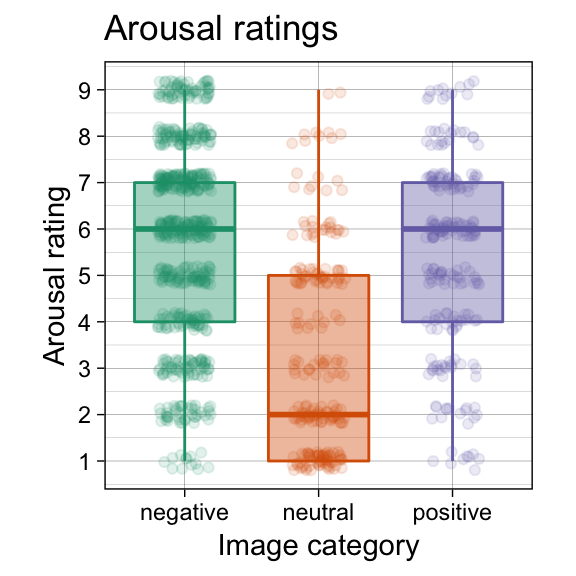

=> Arousal ratings depend on the image category.

### Valence ratings

```r
df %>%
  group_by(emo3) %>%
  summarize(val = mean(valence))
```

| emo3 | val |
| --- | --- |
| negative | 2.871716 |
| neutral | 5.552511 |
| positive | 7.436937 |

Within-Subjects ANOVA

```r
df %>%
  aov(data = ., valence ~ emo3 + Error(id/emo3)) %>%
  {. ->> mdl2 } %>%
  summary()
```

```
##
## Error: id
##      Df Sum Sq Mean Sq
## emo3  1  2.156   2.156
##
## Error: id:emo3
##      Df Sum Sq Mean Sq
## emo3  2   2431    1215
##
## Error: Within
##             Df Sum Sq Mean Sq F value Pr(>F)
## emo3         2   1428   713.8   288.7 <2e-16 ***
## Residuals 1082   2675     2.5
## ---
## Signif. codes:  0 '***' 0.001 '**' 0.01 '*' 0.05 '.' 0.1 ' ' 1
```

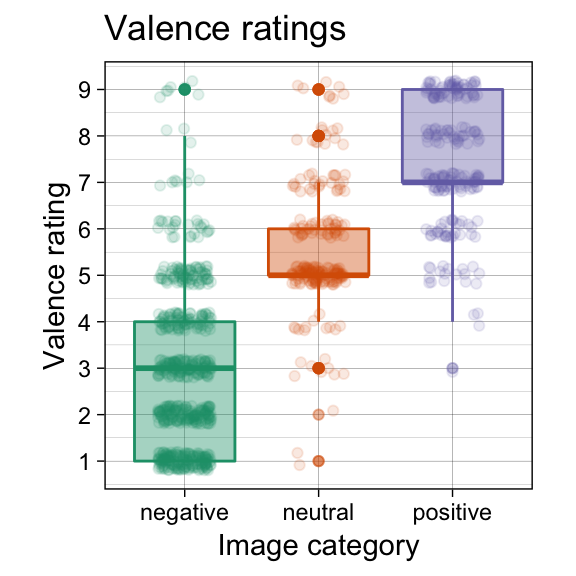

=> On the arousal scale, negative and positive images are rated similarly with high values. On the valence scale, negative images are rated lowest, neutral as neutral, and positive as high in valence.

This shows that most participants followed instructions and that images were effective in eliciting the purposed emotions.

### Heart rate deceleration

Do the images affect heart rate?

“Dunn 2010: Overall, participants showed an HR deceleration when viewing the images, a finding consistent with an initial orienting response (e.g., Bradley, 2000). HR deceleration was greater for negative images than for positive and neutral images, F(2, 51) = 3.29, p < .05 (cf. Dunn et al., 2009).”

```r
df %>%
  group_by(emo3) %>%
  summarize(hr_mean = mean(psc),
            hr_sd = sd(psc))
```

| emo3 | hr_mean | hr_sd |
| --- | --- | --- |
| negative | -4.291291 | 5.948979 |
| neutral | -5.073644 | 5.163242 |
| positive | -5.023548 | 5.349141 |

=> Data shows HR deceleration to images (in the means).

Let’s check with Within-Subjects ANOVA:

```r
df %>%
  aov(data = ., psc ~ emo3 + Error(id/emo3)) %>%
  {. ->> mdl3 } %>%
  summary()
```

```
##
## Error: id
##      Df Sum Sq Mean Sq
## emo3  1  190.5   190.5
##
## Error: id:emo3
##      Df Sum Sq Mean Sq
## emo3  2  57.62   28.81
##
## Error: Within
##             Df Sum Sq Mean Sq F value Pr(>F)
## emo3         2    132   66.08   2.056  0.128
## Residuals 1082  34768   32.13
```

=> ANOVA analysis does **not** show difference in deceleration between images (different from Dunn et al. 2010). So, **our arousal induction partly failed**. [From here I will say that since the HR measure did not work, I will focus on the arousal ratings.]

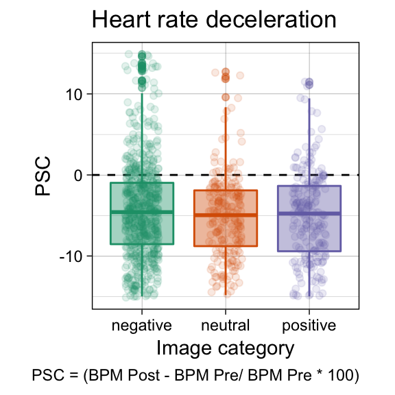

## 2. Correlations

### a. Correlation : HR x arousal ratings

| coef | pval | cimin | cimax | n |
| --- | --- | --- | --- | --- |
| 0.05424669 | 0.07368265 | -0.005202183 | 0.1133135 | 1088 |

=> not significant (for Dunn it was: r = .38)

### b. Correlation : HR x valence ratings

| coef | pval | cimin | cimax | n |
| --- | --- | --- | --- | --- |
| -0.07275023 | 0.0163916 | -0.1316133 | -0.01337596 | 1088 |

### c. Correlation : Interoception x arousal ratings

| coef | pval | cimin | cimax | n |
| --- | --- | --- | --- | --- |
| -0.1430358 | 2.169415e-06 | -0.2007612 | -0.08432047 | 1088 |

=> **very** significant (Dunn: not significant).

### d. Correlation : Interoception x valence ratings

| coef | pval | cimin | cimax | n |
| --- | --- | --- | --- | --- |
| 0.01627683 | 0.5917462 | -0.04319706 | 0.07563577 | 1088 |

=> Not significant (Dunn: not significant).

## 3. Effect of the cardiac feedback on subjective ratings

### a. Mixed MR ANOVA model for arousal ratings

```r
df %>%
  aov(data = ., arousal ~ emo3 + fb * iacc_bin + Error(id/(emo3+fb))) %>%
  {. ->> mdl5 } %>%
  summary()
```

```
##
## Error: id
##      Df Sum Sq Mean Sq
## emo3  1  7.477   7.477
##
## Error: id:emo3
##      Df Sum Sq Mean Sq
## emo3  2  608.8   304.4
##
## Error: id:fb
##      Df Sum Sq Mean Sq
## emo3  1  20.15   20.15
##
## Error: Within
##               Df Sum Sq Mean Sq F value  Pr(>F)
## emo3           2    491  245.27  56.522 < 2e-16 ***
## fb             1      2    1.81   0.417 0.51833
## iacc_bin       1     39   38.56   8.885 0.00294 **
## fb:iacc_bin    1     26   25.57   5.893 0.01536 *
## Residuals   1078   4678    4.34
## ---
## Signif. codes:  0 '***' 0.001 '**' 0.01 '*' 0.05 '.' 0.1 ' ' 1
```

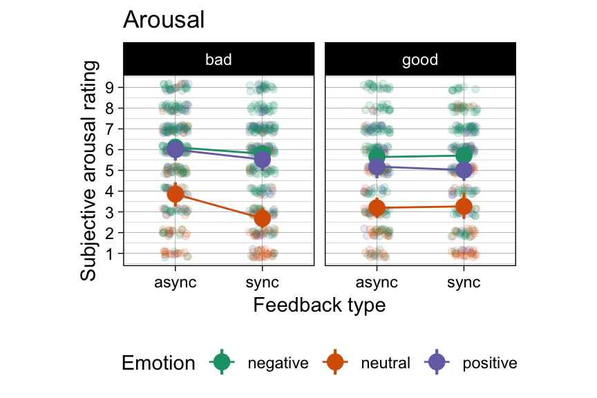

- **Main effect** of Emotion
- **Main effect** of IAcc
- **Interaction** : Effect of feedback only for low IAcc (bad interoceptors)

Same graph without image category separation

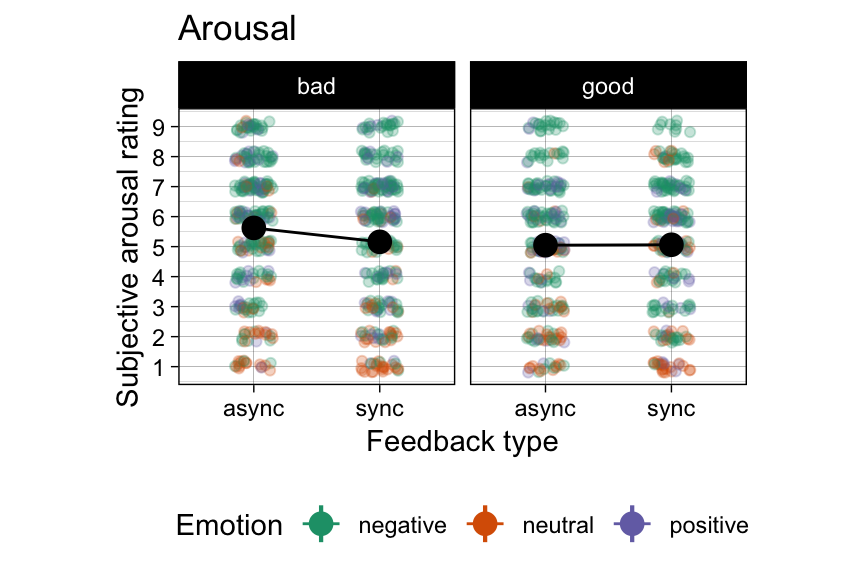

#### Calculate effect sizes (Partial Eta Squares)

```r
library(DescTools)
# https://rdrr.io/cran/DescTools/man/EtaSq.html
EtaSq(mdl5, type = 1, anova=FALSE)
```

```
##             eta.sq  eta.sq.part eta.sq.gen
## emo3            NA 0.0949118204         NA
## fb              NA 0.0003871348         NA
## iacc_bin        NA 0.0081746400         NA
## fb:iacc_bin     NA 0.0054368238         NA
```

#### Assumptions check

1. Errors (a.k.a. residuals) are normally distributed (qqnorm and hist)
2. Variances are homogeneous (heteroscedasticity) : Verified using Levene’s Test for Homogeneity of Variances
3. Model effects are additive · Verified using the Tukey 1-df Test for Nonadditivity
4. Errors are independent

### b. Linear Mixed Model for arousal ratings

Run the same analysis but using a linear mixed model (might be more adequate than ANOVAs https://www.r-bloggers.com/how-to-do-repeated-measures-anovas-in-r/)

```r
df %>%
  lmer(arousal ~ emo3 + fb * iacc_bin + (1|id), data=., REML=TRUE) %>%
  {. ->> mdl6 } %>%
  summary()
```

```
## Linear mixed model fit by REML. t-tests use Satterthwaite's method [
## lmerModLmerTest]
## Formula: arousal ~ emo3 + fb * iacc_bin + (1 | id)
##    Data: .
##
## REML criterion at convergence: 4553.4
##
## Scaled residuals:
##      Min       1Q   Median       3Q      Max
## -2.76841 -0.70426  0.06461  0.73468  2.99856
##
## Random effects:
##  Groups   Name        Variance Std.Dev.
##  id       (Intercept) 0.8131   0.9017
##  Residual             3.6191   1.9024
## Number of obs: 1088, groups:  id, 28
##
## Fixed effects:
##                      Estimate Std. Error        df t value Pr(>|t|)
## (Intercept)            6.2582     0.2563   34.3187  24.418  < 2e-16 ***
## emo3neutral           -2.5289     0.1491 1057.0515 -16.964  < 2e-16 ***
## emo3positive          -0.3695     0.1484 1057.3668  -2.490  0.01292 *
## fbsync                -0.4480     0.1581 1057.9338  -2.834  0.00469 **
## iacc_bingood          -0.6791     0.3820   31.1391  -1.778  0.08523 .
## fbsync:iacc_bingood    0.4642     0.2319 1057.3172   2.002  0.04554 *
## ---
## Signif. codes:  0 '***' 0.001 '**' 0.01 '*' 0.05 '.' 0.1 ' ' 1
##
## Correlation of Fixed Effects:
##             (Intr) em3ntr em3pst fbsync icc_bn
## emo3neutral -0.150
## emo3positiv -0.149  0.256
## fbsync      -0.303  0.018  0.003
## iacc_bingod -0.647  0.000  0.001  0.202
## fbsync:cc_b  0.208 -0.015 -0.008 -0.682 -0.302
```

Plot mixed linear model fit

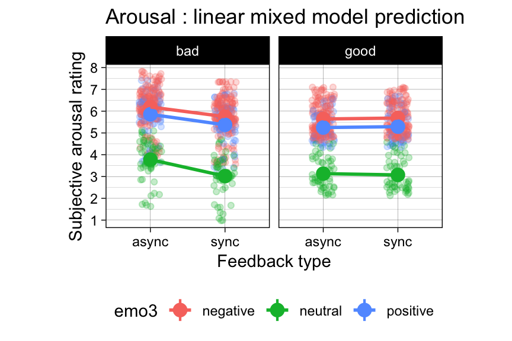

### c. Mixed MR ANOVA model for valence ratings

```r
df %>%
  aov(data = ., valence ~ emo3 + fb * iacc_bin + Error(id/(emo3+fb))) %>%
  {. ->> mdl7 } %>%
  summary()
```

```
##
## Error: id
##      Df Sum Sq Mean Sq
## emo3  1  2.156   2.156
##
## Error: id:emo3
##      Df Sum Sq Mean Sq
## emo3  2   2431    1215
##
## Error: id:fb
##      Df Sum Sq Mean Sq
## emo3  1  4.871   4.871
##
## Error: Within
##               Df Sum Sq Mean Sq F value Pr(>F)
## emo3           2 1427.5   713.8 288.999 <2e-16 ***
## fb             1    0.6     0.6   0.235  0.628
## iacc_bin       1    2.1     2.1   0.861  0.354
## fb:iacc_bin    1    4.6     4.6   1.871  0.172
## Residuals   1078 2662.4     2.5
## ---
## Signif. codes:  0 '***' 0.001 '**' 0.01 '*' 0.05 '.' 0.1 ' ' 1
```

=> No effects (as predicted)

Plot on a graph:

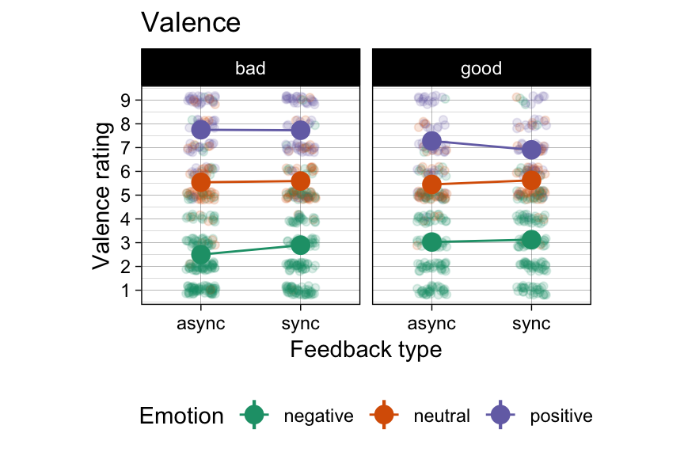

Same graph without image category separation

[figure not shown]

```r
df %>%
  lmer(valence ~ emo3 + fb * iacc_bin + (1|id), data=., REML=TRUE) %>%
  {. ->> mdl8 } %>%
  summary()
```

```
## Linear mixed model fit by REML. t-tests use Satterthwaite's method [
## lmerModLmerTest]
## Formula: valence ~ emo3 + fb * iacc_bin + (1 | id)
##    Data: .
##
## REML criterion at convergence: 4057.3
##
## Scaled residuals:
##     Min      1Q  Median      3Q     Max
## -2.8722 -0.6933 -0.1464  0.6261  4.1099
##
## Random effects:
##  Groups   Name        Variance Std.Dev.
##  id       (Intercept) 0.1493   0.3864
##  Residual             2.3448   1.5313
## Number of obs: 1088, groups:  id, 28
##
## Fixed effects:
##                      Estimate Std. Error        df t value Pr(>|t|)
## (Intercept)            2.7346     0.1375   49.7664  19.881   <2e-16 ***
## emo3neutral            2.6830     0.1199 1057.9373  22.370   <2e-16 ***
## emo3positive           4.5857     0.1194 1058.6966  38.421   <2e-16 ***
## fbsync                 0.2467     0.1271 1059.5529   1.940   0.0526 .
## iacc_bingood           0.1897     0.1985   39.8024   0.956   0.3450
## fbsync:iacc_bingood   -0.2549     0.1865 1058.3822  -1.366   0.1721
## ---
## Signif. codes:  0 '***' 0.001 '**' 0.01 '*' 0.05 '.' 0.1 ' ' 1
##
## Correlation of Fixed Effects:
##             (Intr) em3ntr em3pst fbsync icc_bn
## emo3neutral -0.225
## emo3positiv -0.223  0.256
## fbsync      -0.456  0.018  0.003
## iacc_bingod -0.638  0.000  0.002  0.313
## fbsync:cc_b  0.312 -0.015 -0.008 -0.682 -0.469
```

### Assumptions check for linear mixed model

1. Linearity and homoskedasticity
- **Linearity**: the pattern in the results should not be non-linear (e.g. a U-shape, curvy pattern, etc)
- **Homoskedasticity**: “the residuals of your model need to roughly have a similar amount of deviation from your predicted values.”
2. **Collinearity** : A VIF factor of 1 indicates no collinearity. Larger VIF factors (>2) are problematic.
3. **Normality of residuals** : The histogram should show a normal distribution (bell shape) around 0, and the QQ-plot should show points falling on the diagnonal.
4. **Influential points** : Use `Influence.ME` package
5. **Independence** : Mixed model is used to take into account non-independence of values (per subject, per session, etc).

```r
# Adapted VIF function from [here](https://github.com/aufrank/R-hacks/blob/master/mer-utils.R).
vif.mer <- function (fit) {
## adapted from rms::vif
v <- vcov(fit)
nam <- names(fixef(fit))
## exclude intercepts
ns <- sum(1 * (nam == "Intercept" | nam == "(Intercept)"))
if (ns > 0) {
v <- v[-(1:ns), -(1:ns), drop = FALSE]
nam <- nam[-(1:ns)] }
d <- diag(v)^0.5
v <- diag(solve(v/(d %o% d)))
names(v) <- nam
v }

# Apply function to our model
vif.mer(mdl8)
```

```
##         emo3neutral        emo3positive              fbsync
##            1.070389            1.070029            1.868143
##        iacc_bingood fbsync:iacc_bingood
##            1.281595            2.158442
```

### Results

# Interpretation

- perhaps effect is present but not due to synchronicity (just to feedback itself) : need a baseline (Limit 1)
- perhaps feedback is not precise enough, or to adjust delays for each person
- perhaps HR measure is not precise enough (I averaged over a time window ) (since i fail to show different deceleration per emotion, so manipulation not completely effective)
- IAcc criticized (I acquired control for Depression, Anxiety, but not analysed).

# Extras

## Summary

Summarise in a table

```r
df %>%
  group_by(id, fb, emo3) %>%
  #filter(!is.na(iacc_bin)) %>%
  summarize(mean = mean(arousal, na.rm = T), # mean
            se = sd(arousal, na.rm = T)/ sqrt(n()),  # standard error
            n = n(),
            ia = mean(iacc)
  )
```

| id | fb | emo3 | mean | se | n | ia |
| --- | --- | --- | --- | --- | --- | --- |
| 1 | async | negative | 7.090909 | 0.4359847 | 11 | 0.3159800 |
| 1 | async | neutral | 4.200000 | 0.8602325 | 5 | 0.3159800 |
| 1 | async | positive | 8.000000 | 0.3162278 | 5 | 0.3159800 |
| 1 | sync | negative | 7.769231 | 0.3028465 | 13 | 0.3159800 |
| 1 | sync | neutral | 5.500000 | 0.8660254 | 4 | 0.3159800 |
| 1 | sync | positive | 7.250000 | 0.6291529 | 4 | 0.3159800 |
| 2 | async | negative | 3.384615 | 0.3108809 | 13 | 0.6987746 |
| 2 | async | neutral | 1.750000 | 0.4787136 | 4 | 0.6987746 |
| 2 | async | positive | 3.500000 | 0.6454972 | 4 | 0.6987746 |
| 2 | sync | negative | 3.538462 | 0.5384615 | 13 | 0.6987746 |

[output cut: 157 more lines]

## Calculate HR x Rating correlations

Compute correlations between arousal ratings and the heart rate (as psc).

```r
df %>%
  group_by(id,fb) %>%
  # [     z score correlation estimates     ] %>%
  summarise(coef=cor.test(psc, arousal)$estimate,
            pval=cor.test(psc, arousal)$p.value,
            cimin=cor.test(psc, arousal)$conf.int[1],
            cimax=cor.test(psc, arousal)$conf.int[2],
            nn = n())
```

| id | fb | coef | pval | cimin | cimax | nn |
| --- | --- | --- | --- | --- | --- | --- |
| 1 | async | -0.07710866 | 0.73972748 | -0.49240486 | 0.36678729 | 21 |
| 1 | sync | 0.06212604 | 0.78906690 | -0.37974512 | 0.48091516 | 21 |
| 2 | async | 0.36299934 | 0.10580572 | -0.08145097 | 0.68702752 | 21 |
| 2 | sync | -0.15797180 | 0.48259770 | -0.54338930 | 0.28244834 | 22 |
| 3 | async | 0.08047571 | 0.81404449 | -0.54574536 | 0.64901909 | 11 |
| 3 | sync | 0.33577502 | 0.31272523 | -0.33071326 | 0.77878482 | 11 |
| 4 | async | -0.14894409 | 0.51934020 | -0.54555332 | 0.30217147 | 21 |
| 4 | sync | 0.19789315 | 0.41672618 | -0.28163047 | 0.59832229 | 19 |
| 7 | async | -0.57228096 | 0.03246890 | -0.84598509 | -0.05988496 | 14 |
| 7 | sync | -0.13694027 | 0.68805222 | -0.68088277 | 0.50436700 | 11 |

[output cut: 46 more lines]

```r
df %>%
  group_by(iacc_bin) %>%
  # [     z score correlation estimates     ] %>%
  summarise(n = n()/50)
```

| iacc_bin | n |
| --- | --- |
| bad | 11.66 |
| good | 10.10 |

```r
df %>%
  group_by(id,fb,emo3) %>%
  # [     z score correlation estimates     ] %>%
  summarise(trials = n(),
            missing = 50 - n()) #%>%
```

| id | fb | emo3 | trials | missing |
| --- | --- | --- | --- | --- |
| 1 | async | negative | 11 | 39 |
| 1 | async | neutral | 5 | 45 |
| 1 | async | positive | 5 | 45 |
| 1 | sync | negative | 13 | 37 |
| 1 | sync | neutral | 4 | 46 |
| 1 | sync | positive | 4 | 46 |
| 2 | async | negative | 13 | 37 |
| 2 | async | neutral | 4 | 46 |
| 2 | async | positive | 4 | 46 |
| 2 | sync | negative | 13 | 37 |

[output cut: 157 more lines]

```r
  #mutate(keep = case_when(missing > 5 ~ 'exclude'))

#higher than 3 missing?
# 3(7,12), 9 (9,15), 23 (7,9), 30 (0,5), 35 (16,11), 36 (10,14), 37 (5,3), 38 (4,2), 49(5,1), 51(4,10),54(4,2), 57 (8,2)
#3,9,23,30,35,36,37,38,49,51,54,57  (12) > 5
#-> 3,9,23,35,36,37,51,57  > 6

#38, 49
```

# Visualise HR for each participant

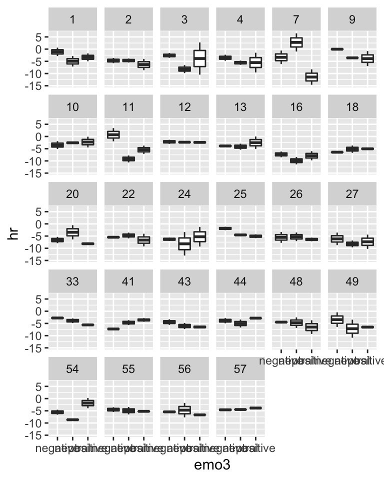

```r
df %>%
  group_by(id,fb,emo3) %>%
  na.omit() %>%
  #[ remove outliers in psc ] %>%
  summarise(hr = mean(psc)) %>%
  ggplot(aes(x=emo3, y = hr)) +
    geom_boxplot() +
    facet_wrap(~id)
```

T-test on the differences:

```r
df %>%
  group_by(iacc_bin, id, emo3) %>%
  mutate(diff = mean(arousal[fb=='async']) - mean(arousal[fb=='sync'],
            n = n())) %>%
  summarise(means = mean(diff)) %>%
  t.test(data = ., means ~ iacc_bin,  alternative = "two.sided", paired = FALSE)
```

```
##
##  Welch Two Sample t-test
##
## data:  means by iacc_bin
## t = 1.5324, df = 80.276, p-value = 0.1293
## alternative hypothesis: true difference in means is not equal to 0
## 95 percent confidence interval:
##  -0.1285691  0.9898313
## sample estimates:
##  mean in group bad mean in group good
##         0.46025499         0.02962385
```